# Encuesta a estudiantes de Cursado en Formato Combinado (CFC) - FCE

Síntesis 2026 (1º y 2º semestre)

Fecha de publicación

1 de noviembre de 2026

# Ficha técnica

- La encuesta fue autoadministrada mediante formulario *on line* en dos olas, con el **mismo cuestionario** en ambas:
  - **1º semestre**: **517 respuestas** (del 11/05/2026 al 05/06/2026)
  - **2º semestre**: **105 respuestas** (del 14/09/2026 al 10/10/2026).

Decisiones/criterios de procesamiento:

- **Respuestas múltiples:** los porcentajes se calculan sobre quienes respondieron cada pregunta, no sobre el total de marcas (las sumas pueden superar 100%).
- **Grilla de preguntas sobre aulas virtuales:** en el 1º semestre la configuración permitía seleccionar más de una alternativa y 35 casos registraron más de una marca en algún ítem; se aplicó el criterio conservador ya documentado (misma dirección: se conserva la menos extrema; contradictorias: se anula el ítem). **Para el 2º semestre la grilla se corrigió a opción única y no se registró ninguna marca múltiple** (0 casos), por lo que esos datos no requirieron limpieza.
- **Inconsistencias:** 19 casos (16 del 1º semestre y 3 del 2º) declararon más materias CFC que materias totales; se excluyen solo para el cálculo de la proporción de materias CFC.

# Participación y composición de las olas

La participación del 2º semestre (105 respuestas) representa una caída de 80% respecto del 1º (517). Esto no invalida la comparación (dado que los descriptivos de la ola 2 son estables), sin embargo las desagregaciones deben interpretarse con más cautela debido a que pueden haber categorías con relativamente pocas frecuencias.

Por otro lado, las olas difieren en composición, algo a tener presente al comparar resultados. Particularmente, en el 2º semestre casi el 90% de quienes respondieron ya tenía experiencia previa en CFC y, adicionalmente, crece el peso del Ciclo profesional en las materias cursadas por el estudiantado que respondió la encuesta ($45.7$%).

Experiencia en CFC según ola

| Ola | Experiencia previa | Primera experiencia |
| --- | --- | --- |
| 1º semestre | 377 (72,9%) | 140 (27,1%) |
| 2º semestre | 94 (89,5%) | 11 (10,5%) |

Ciclo de las materias cursadas según ola (%)

| Ola | Ciclo básico | Ciclo profesional | Ambos ciclos |
| --- | --- | --- | --- |
| 1º semestre | 48,0% | 39,3% | 12,8% |
| 2º semestre | 31,4% | 45,7% | 22,9% |

# Perfil de quienes respondieron

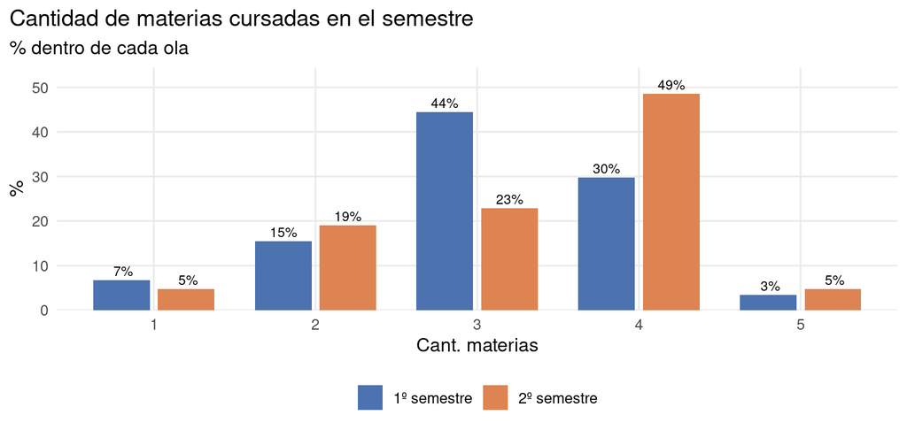

Peso del CFC en la inscripción según ola (excluye inconsistencias)

| Ola | Cant. estudiantes | Cant. materias (promedio) | Cant. materias (mediana) | Materias CFC (promedio) | Materias CFC (mediana) | Proporción CFC (media) | Cursan 100% en CFC |
| --- | --- | --- | --- | --- | --- | --- | --- |
| 1º semestre | 501 | 3,12 | 3 | 2,04 | 2 | 68,1% | 31,9% |
| 2º semestre | 102 | 3,33 | 4 | 1,95 | 2 | 60,8% | 22,5% |

El peso relativo del CFC en la inscripción es algo menor en el 2º semestre (tanto en la proporción media de materias CFC como en el porcentaje que cursa exclusivamente en CFC), en un contexto en que quienes respondieron cursan en promedio algo más de materias.

# La elección del CFC

Motivos de re-elección del CFC según ola, solo experiencia previa (bases: 1º sem = 377, 2º sem = 94)

| Motivo | 1º semestre | 2º semestre |
| --- | --- | --- |
| Organización de horarios y tiempos de estudio | 79,3% | 83,0% |
| Compatibilidad con trabajo u otras responsabilidades | 69,0% | 74,5% |
| Preferencia por combinar/alternar presencial y virtual | 37,4% | 34,0% |
| Era la comisión disponible | 12,2% | 8,5% |
| El/la docente o la cátedra | 9,5% | 12,8% |

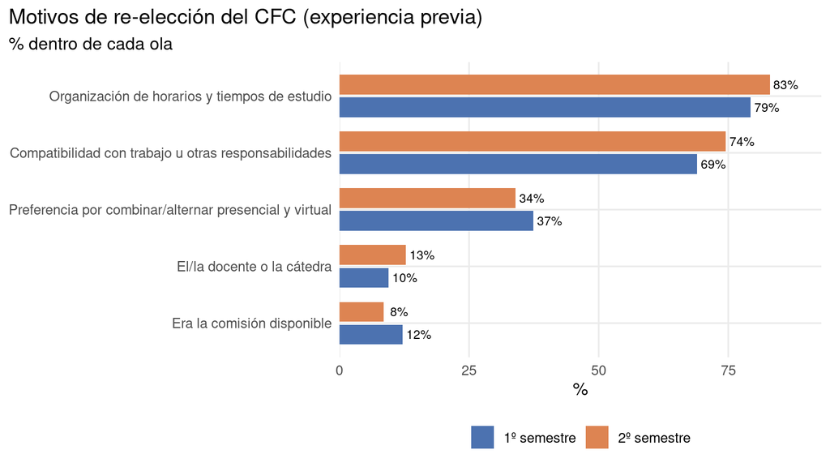

En el grupo de primera experiencia del 2º semestre la base es muy chica (n = 11), por lo que sus porcentajes no se tabulan por separado al no resultar cifras robustas; sin embargo, a nivel agregado sus respuestas siguen el patrón del 1º semestre.

# Modalidad de asistencia a clases

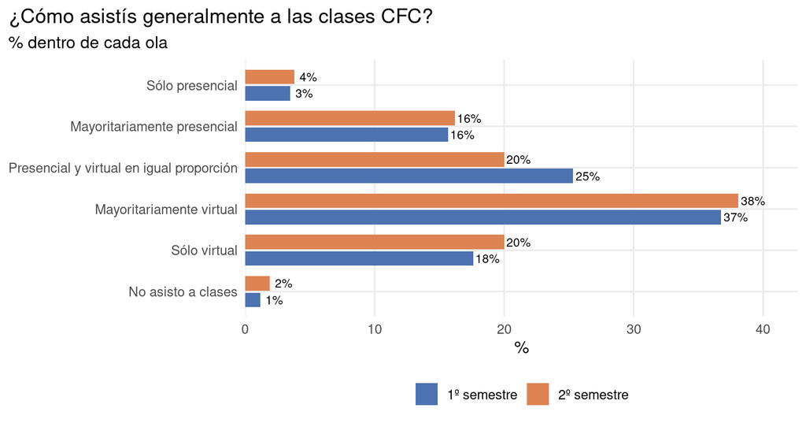

Modalidad de asistencia agregada según ola (%)

[output not shown]

Modalidad de asistencia según ola, considerando solo estudiantes con experiencia previa (%)

| Ola | Predominio presencial | Equilibrado | Predominio virtual |
| --- | --- | --- | --- |
| 1º semestre | 13,5% | 23,3% | 63,1% |
| 2º semestre | 19,1% | 21,3% | 59,6% |

Quienes no asisten a clases siguen siendo marginales: 8 casos en el total de ambas olas (6 y 2 respectivamente), con el mismo perfil ya descripto en el informe del 1º semestre: acceden a los contenidos por el aula virtual y las clases grabadas, y declaran que volverían a cursar en CFC.

# Beneficios y dificultades percibidas

La estructura de beneficios y dificultades se mantiene entre semestres: los beneficios de la presencialidad siguen encabezados por el *contacto más directo con docentes* y los de la virtualidad por la *flexibilidad de lugar y horario*; la dificultad dominante de la presencialidad sigue siendo el *traslado* (cerca del 80% en ambas olas). El cambio más notorio del 2º semestre es el aumento de quienes *no encuentran dificultades en el cursado virtual* (36% vs 45%), consistente con una muestra formada por estudiantes con más experiencia en el formato.

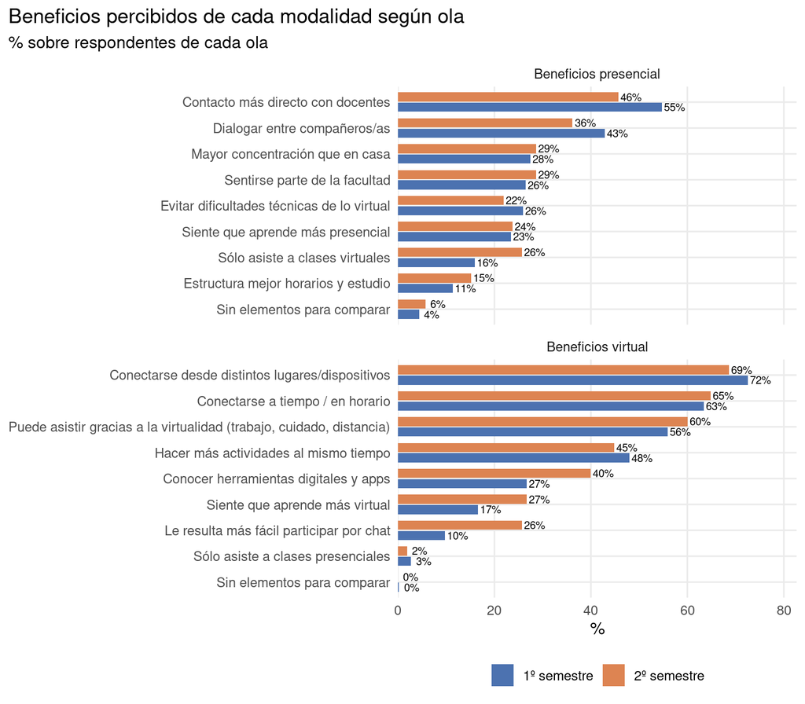

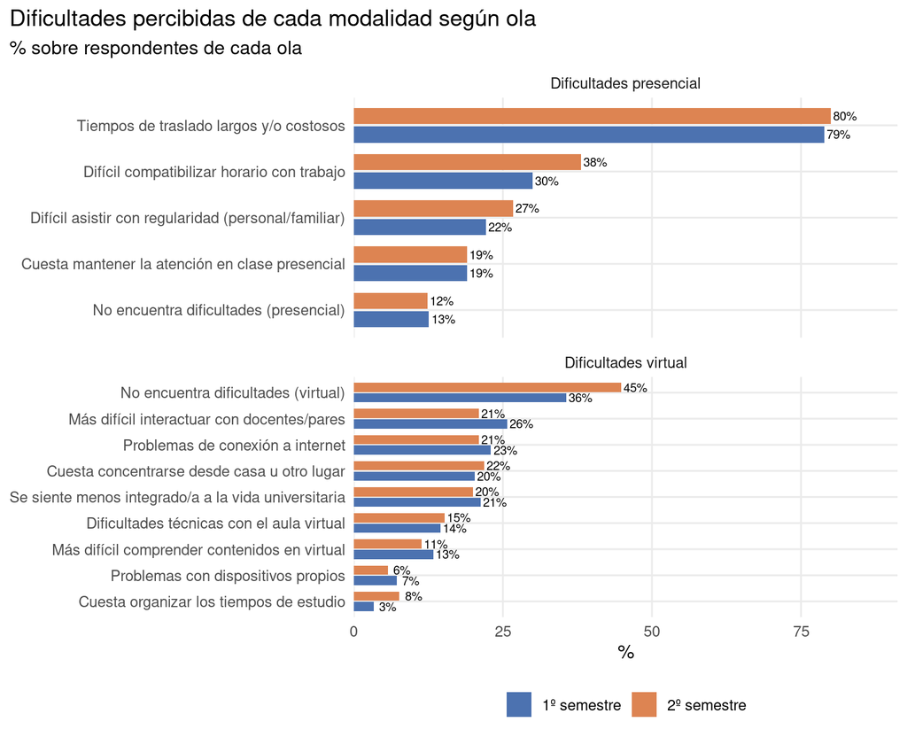

Se replica además la tensión entre valoración y comportamiento identificada en el informe del 1º semestre: como muestra la siguiente tabla, entre quienes cursan con predominio virtual, el 51% (1º semestre) y el 46% (2º semestre) reconocen igualmente el contacto directo con docentes y/o que se aprende más en clases presenciales, al tiempo que alrededor de dos tercios señalan que es la virtualidad la que les permite asistir a clases. La elección de la virtualidad sigue respondiendo a razones de acceso y logística (traslado, trabajo) más que a una preferencia pedagógica.

Estudiantes con predominio virtual: reconocimiento de beneficios presenciales y acceso por virtualidad, según ola (%)

| Ola | Cant. estudiantes | Contacto más directo con docentes | Siente que aprende más presencial | Al menos uno de los dos | Puede asistir gracias a la virtualidad |
| --- | --- | --- | --- | --- | --- |
| 1º semestre | 287 | 47,7% | 12,2% | 51,2% | 65,2% |
| 2º semestre | 63 | 33,3% | 15,9% | 46,0% | 69,8% |

# Percepción de las aulas virtuales

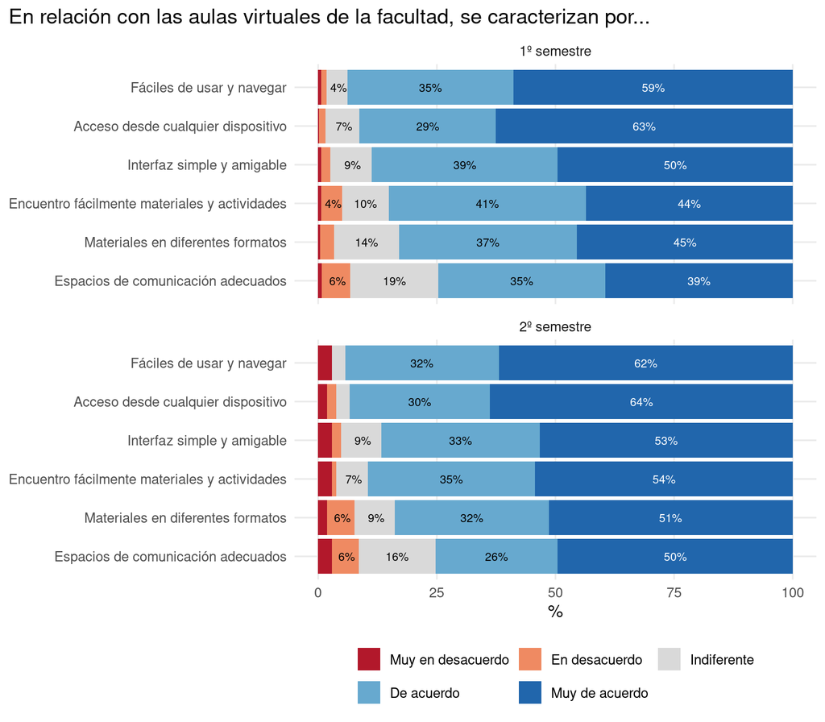

Media de cada ítem de aulas virtuales según ola (escala 1-5)

| Ola | Fáciles de usar y navegar | Interfaz simple y amigable | Encuentro fácilmente materiales y actividades | Acceso desde cualquier dispositivo | Espacios de comunicación adecuados | Materiales en diferentes formatos |
| --- | --- | --- | --- | --- | --- | --- |
| 1º semestre | 4,5 | 4,35 | 4,23 | 4,52 | 4,07 | 4,25 |
| 2º semestre | 4,5 | 4,32 | 4,37 | 4,51 | 4,13 | 4,26 |

Los 9 comentarios abiertos del 2º semestre (listados en el anexo) reiteran los ejes cualitativos del 1º: demoras o falta de respuesta en foros y mensajes, y heterogeneidad entre cátedras en el uso y la organización de las aulas. El diagnóstico sigue apuntando a las prácticas de uso más que a la plataforma.

# Intención de continuar en CFC

La intención de volver a cursar en CFC se mantiene en niveles muy altos y estables en ambas olas, el indicador más contundente de la valoración general del formato.

¿Volverías a cursar otra materia en CFC? según ola (%)

| Ola | Si | No sé / No lo tengo decidio | No |
| --- | --- | --- | --- |
| 1º semestre | 94,8% | 4,3% | 1,0% |
| 2º semestre | 95,2% | 3,8% | 1,0% |

Motivos de quienes no volverían a cursar en CFC ( 6 casos en ambas olas):

- (1º semestre) No volvería a cursar una materia de esa forma ya que me cuesta más organizar mis horarios de estudio, comprender los conceptos y consultar dudas
- (1º semestre) No es de mi agrado, a veces no hay clases y tenés que seguir estudiando por tu cuenta
- (1º semestre) Hacer una materia en formato CFC sin la posibilidad de ir a clases presenciales como es el caso de estadistica 1.
- (1º semestre) Porque entiendo mas viniendo presencial, en lo virtual me pierdo
- (1º semestre) Es correcto para las personas que se les dificulta el ir a clase, les permite acceder desde su lugar, pero la clase de vuelve extremadamente difícil de seguir en el aula porque el profesor no puede usar el pizarrón y solo depende de la computadora y Powerpoint. Para el presencial (mí caso) dificulta el entendimiento de los temas.
- (2º semestre) Porque dan solo unos dias hibridos y después dan todo virtual. Se dificulta cuando cursas presencial otras materias. No es lo mismo, es muy poco didáctico y se aprende poco o es mas difícil, mas si la materia es practica.

# Síntesis

**NotaSíntesis comparativa 2026**

- **Estabilidad como resultado central**: motivos de elección, modalidades de asistencia, estructura de beneficios y dificultades, valoración de aulas virtuales e intención de continuar se replican entre semestres. El diagnóstico del 1º semestre se consolida como caracterización estructural del CFC, y no meramente coyuntural.
- **El aparente avance de la virtualización es efecto composición**: controlando por experiencia previa, la modalidad de asistencia no cambió entre semestres.
- **Menor cantidad de respuestas entre olas** (517 vs 105 respuestas): dificulta generalizar algunas conclusiones con mayor granularidad.
- **Aulas virtuales**: los espacios de comunicación siguen siendo el punto débil; la mejora en la facilidad para encontrar materiales es el único movimiento apreciable. Los comentarios reiteran que el déficit está en las prácticas de las cátedras (foros sin respuesta, organización heterogénea), no en la plataforma.

# Anexo: respuestas de texto libre del 2º semestre

**Motivos de elección CFC** (14 respuestas):

- Vivo en el interior de la provincia de Córdoba
- Poder ahorrarme el viaje a la ciudad y poder cursar desde mi casa
- Me ahorra tiempo de viaje, ya que vivo lejos.
- Nunca elegí, me tocó
- Cfc da mucha más libertad, seguridad de poder ver el material de estudio y muchas más herramientas y comodidades.
- al tener 2 boletos al dia del BEC, el CFC me permite asistir a clases los dias que tengo materias 100% en distinto turno (ej clases 8 hs y 18 hs)
- me permite poder volver a ver las clases grabadas o conectarme en situaciones adversas
- Me permitió no perderme las clases, ya que vivo en el interior
- Me ahorra costos de viaje y estadía
- Viajo desde el interior
- especialmente teniendo en cuenta el tiempo de viaje que tengo hasta la facultad.
- Distancia de la facultad y domicilio
- Me permite hacer materias de distintos semestres sin que se me superpongan horarios.
- No tengo materias este semestre con esta modalidad pero de semestres anteriores es muy útil sobre todo cuando se graba y suben las clases.

**Beneficios clases presenciales** (1 respuestas):

- Me genera una rutina

**Beneficios clases virtuales** (4 respuestas):

- Me permite no gastar tantas horas de viaje al ser del interior
- Siento que también es una forma válida de integrar la facultad
- le da mucha flexibilidad al cursado. Me permite elegir la modalidad que me sea conveniente dependiendo de la dificultad del material, las exigencias de otros compromisos, etc
- Cuando se dificulta por trabajo u otras materias puedo ver las clases grabadas

**Dificultades clases presenciales** (2 respuestas):

- Requiere planificación de transporte y comida, además de la exposición al clima que se me hace peligrosa a veces por enfermedades respiratorias que tengo y diferencias con mi clima de origen
- por cuestiones de salud, soy asmatica y me evita estar mucho tiempo en un espacio cerrado con personas tociendo al lado, cosa que me sucedio hace dias

**Dificultades clases virtuales** (5 respuestas):

- Creo que 1/3 de los profesores, principalmente de los prácticos les molesta y cuesta transmitir la clase y descuidan a alumnos virtuales y a veces perdés las clases por falta de capacitación y voluntad de algunos profesores puntuales, aunque son minoría estos desafortunados casos y cada vez menos
- cuando hay clases presenciales antes o después y una catedra decide dar solo virtual es muy incómodo de asistir a la clase.
- Estando en meet, los profes se ponen insistentes con que asistamos a clases (siento que, que no te haya visto durante el cuatrimestre puede condicionante en un final oral)
- POR ALLI SE ME HACEMUY DIFICIL CONCTARME DADO QUE ME PIDEN VARIAS VECES LA CLAVE Y SE DIFICULTA INGRESAR
- La visibilidad de lo que explica el profesor si escribe en el pizarron

**Comentarios sobre los desacuerdos sobre aulas virtuales (2º semestre)**

Se registraron 9 comentarios:

- Porque es fácil de utilizar y de encontrar cualquier información respecto al programa o método de evaluación de los profesores.
- A veces los espacios de comunicación directo con los docentes se pierden entre tanto contenido y/o se mezclan con los espacios de discusión / dudas. Llegan muchos mails del docente respondiendo dudas sobre ejercicios y se pierden los que son mensajes importantes.
- Siento que la interfaz del aula virtual es muy “rústica”, no es un problema grande porque no me impide estudiar, pero se podría mejorar ese aspecto. Y por otro lado, estaría buenísimo agregar la opción del aula virtual en “Modo Oscuro”, debido a que muchas veces estudio de noche y la luz blanca y fuerte de la página me cansa bastante los ojos
- No hay materiales en formato digital
- no siempre hay material disponible en el aula virtual. Ej: en conta 3 recursado Quadr,o nos habilitan los excel y ejercicios una semana despues de la clase practica, tampoco hay material como una guia de trabajos practicos o ejercicios. algo que se le reclamo al docente pero se niegan a enviar “porque no le gustan los enunciados”. Solicité que nos den los enunciados para ir con los ejercicios hechos para la clase de repaso del parcial y se negaron nuevamente los docentes de las clases practicas. no sabemos de donde obtener ejercicos para practicar. pretenden que hagamos el mismo ejercicio una y otra vez
- Es depende la materia y profesor. Muchos son catedras que ponen el link del meet y es lo unico “virtual” o colocan videos de la pandemia y nada mas. Es importante colocar informaciom basica de organizacion de la materia (cronograma de la materia)
- No siempre tenemos materiales en diferentes formatos. Loa profes deberian subir video de aquellos temas específicos que maa nos cuesta entender
- La interfaz no es amigable y aveces los profes no cargan la info o no contestan con rapidez o no la abren
- POR ALI ELSISTEMA NIO TE PERIMTE INGRESAR TE PIDE VARIS VECES LA CLAVE DE ACCESO PUEDE SER POR HORAS PICO DE GESTION DE MUCHOS ALIMNOS. PRO ME PASA COTIDIANAMENTE.